# Walmart Sales Analysis: Electronics vs Appliances (EDA)

Pablo

2026-03-02

```r
knitr::opts_chunk$set(echo=TRUE, message=FALSE, warning=FALSE)
library(tidyverse)
library(lubridate)
library(janitor)
library(effsize)
```

```r
walmart <- read_csv("Walmart.csv") %>%
  clean_names() %>%
  mutate(
    transaction_date = mdy_hm(transaction_date),
    transaction_day  = as.Date(transaction_date),
    revenue          = quantity_sold * unit_price,
    category         = as.factor(category),
    promotion_applied = as.factor(promotion_applied),
    promotion_type   = as.factor(promotion_type)
  ) %>%
  filter(
    transaction_day >= as.Date("2023-12-31"),
    transaction_day <= as.Date("2024-09-16")
  )
```

# Quick checks

```r
glimpse(walmart)
```

```
## Rows: 5,000
## Columns: 30
## $ transaction_id         <dbl> 1, 2, 3, 4, 5, 6, 7, 8, 9, 10, 11, 12, 13, 14, …
## $ customer_id            <dbl> 2824, 1409, 5506, 5012, 4657, 3286, 2679, 9935,…
## $ product_id             <dbl> 843, 135, 391, 710, 116, 630, 238, 409, 106, 40…
## $ product_name           <chr> "Fridge", "TV", "Fridge", "Smartphone", "Laptop…
## $ category               <fct> Electronics, Electronics, Electronics, Electron…
## $ quantity_sold          <dbl> 3, 4, 4, 5, 3, 4, 3, 4, 4, 5, 3, 3, 2, 3, 2, 4,…
## $ unit_price             <dbl> 188.46, 1912.04, 1377.75, 182.31, 499.28, 1465.…
## $ transaction_date       <dttm> 2024-03-31 21:46:00, 2024-07-28 12:45:00, 2024…
## $ store_id               <dbl> 3, 5, 1, 5, 6, 1, 3, 16, 12, 10, 12, 9, 3, 13, …
## $ store_location         <chr> "Miami, FL", "Dallas, TX", "Los Angeles, CA", "…
## $ inventory_level        <dbl> 246, 43, 411, 452, 412, 196, 24, 125, 103, 424,…
## $ reorder_point          <dbl> 116, 70, 94, 87, 99, 80, 52, 92, 129, 88, 135, …
## $ reorder_quantity       <dbl> 170, 212, 252, 112, 177, 210, 287, 178, 172, 25…
```

[output cut: 17 more lines]

```r
table(walmart$category)
```

```
##
##  Appliances Electronics
##        2415        2585
```

```r
table(walmart$promotion_applied)
```

```
##
## FALSE  TRUE
##  2393  2607
```

The variable promotion_applied is a binary indicator that takes the value TRUE when a promotion was applied to a transaction and FALSE when no promotion was applied. In this dataset, 2,607 transactions included a promotion while 2,393 did not, providing a relatively balanced comparison between the two groups. This allows us to meaningfully evaluate whether promotions influence quantity sold and revenue per transaction.

# SMART Question Focus: Compare Electronics vs Appliances Using Required Variables

transaction_date (time)

promotion_applied (promo vs no promo)

promotion_type (types of promo)

The variable promotion_applied is a binary indicator that takes the value TRUE when a promotion was applied to a transaction and FALSE when no promotion was applied. In this dataset, 2,607 transactions included a promotion while 2,393 did not, providing a relatively balanced comparison between the two groups. This allows us to meaningfully evaluate whether promotions influence quantity sold and revenue per transaction.

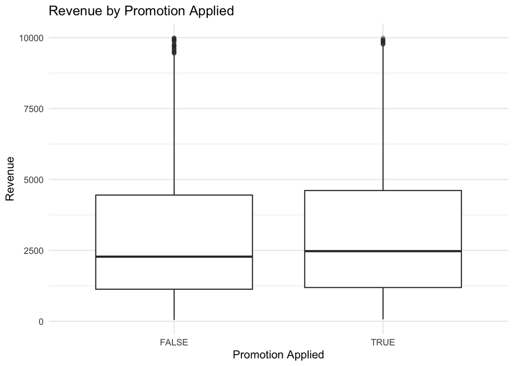

```r
ggplot(walmart, aes(x = promotion_applied, y = revenue)) +
  geom_boxplot(outlier.alpha = 0.3) +
  labs(title = "Revenue by Promotion Applied", x = "Promotion Applied", y = "Revenue") +
  theme_minimal()
```

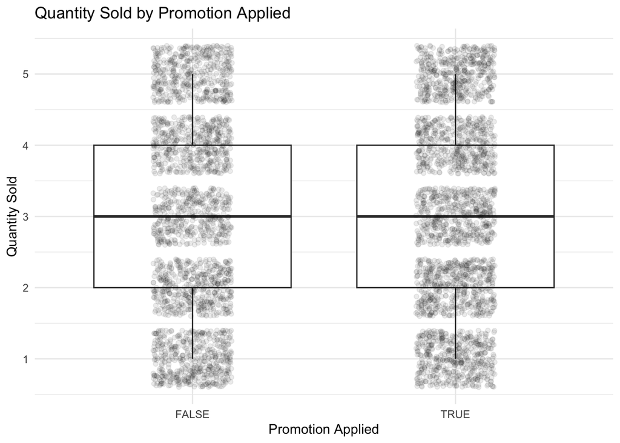

```r
ggplot(walmart, aes(x = promotion_applied, y = quantity_sold)) +
  geom_boxplot(outlier.alpha = 0.3) +
  geom_jitter(width = 0.15, alpha = 0.08) +
  labs(
    title = "Quantity Sold by Promotion Applied",
    x = "Promotion Applied",
    y = "Quantity Sold"
  ) +
  theme_minimal()
```

The boxplot and jittered observations show nearly identical distributions of quantity sold between transactions with and without promotions. The median quantity is approximately three units in both groups, and the interquartile ranges overlap substantially. Visually, there is no clear evidence that applying a promotion increases the number of items purchased per transaction.

Each dot represents one transaction, and the overlapping clusters show that quantity purchased looks nearly identical regardless of whether a promotion was applied.

```r
walmart %>%
  group_by(promotion_applied) %>%
  summarise(
    mean_quantity = mean(quantity_sold),
    sd_quantity = sd(quantity_sold),
    n = n()
  )
```

```
## # A tibble: 2 × 4
##   promotion_applied mean_quantity sd_quantity     n
##   <fct>                     <dbl>       <dbl> <int>
## 1 FALSE                      2.98        1.43  2393
## 2 TRUE                       2.98        1.41  2607
```

```r
t.test(quantity_sold ~ promotion_applied, data = walmart)
```

```
##
##  Welch Two Sample t-test
##
## data:  quantity_sold by promotion_applied
## t = -0.076531, df = 4946.3, p-value = 0.939
## alternative hypothesis: true difference in means between group FALSE and group TRUE is not equal to 0
## 95 percent confidence interval:
##  -0.08192346  0.07576755
## sample estimates:
## mean in group FALSE  mean in group TRUE
##            2.981195            2.984273
```

# Hypothesis test

Null Hypothesis (H0): The mean quantity sold per transaction is the same for transactions with a promotion and transactions without a promotion.

Alternative Hypothesis (H1): The mean quantity sold per transaction is different between transactions with a promotion and transactions without a promotion

The Welch two-sample t-test indicates no statistically significant difference in the mean quantity sold between transactions with and without promotions (p = 0.939). The average quantity sold is approximately 2.98 units in both groups, and the 95% confidence interval includes zero, suggesting that the true difference in means may be zero. Overall, the data provide no evidence that applying a promotion increases the number of items purchased per transaction.

# — Step 3: Effect Size —

```r
cohen.d(quantity_sold ~ promotion_applied, data = walmart)
```

```
##
## Cohen's d
##
## d estimate: -0.002168164 (negligible)
## 95 percent confidence interval:
##       lower       upper
## -0.05766862  0.05333229
```

Cohen d was calculated to evaluate the practical significance of the difference in quantity sold between transactions with and without promotions. The estimated effect size is -0.002, which is classified as negligible. The 95% confidence interval includes zero, further indicating that the difference is not meaningful. Together with the t-test results, this confirms that promotions do not meaningfully affect the number of items purchased per transaction.

# Type of Promotion Check

```r
table(walmart$promotion_type)
```

```
##
##                BOGO                None Percentage Discount
##                 820                3407                 773
```

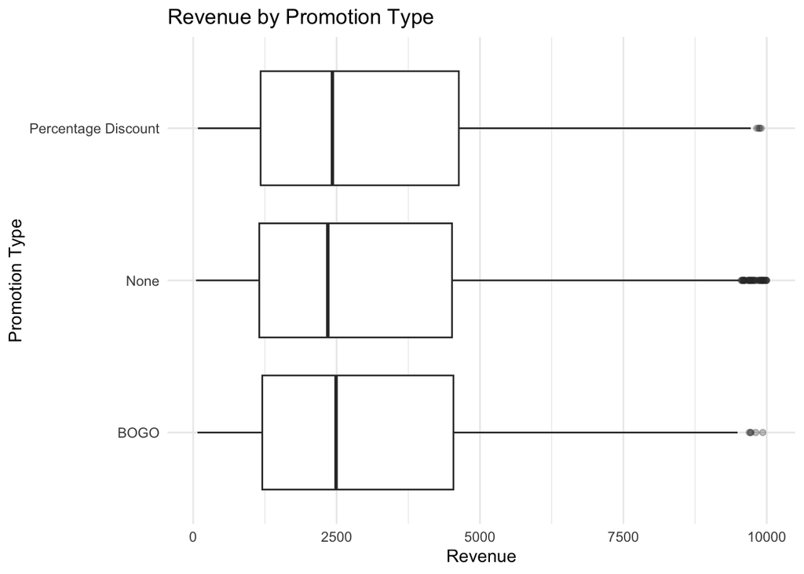

```r
ggplot(walmart, aes(x = promotion_type, y = revenue)) +
  geom_boxplot(outlier.alpha = 0.3) +
  coord_flip() +
  theme_minimal() +
  labs(title = "Revenue by Promotion Type",
       x = "Promotion Type",
       y = "Revenue")
```

```r
top_two <- walmart %>%
  count(promotion_type, sort = TRUE) %>%
  slice(1:2) %>%
  pull(promotion_type)

walmart_two <- walmart %>%
  filter(promotion_type %in% top_two) %>%
  droplevels()

t.test(revenue ~ promotion_type, data = walmart_two)
```

```
##
##  Welch Two Sample t-test
##
## data:  revenue by promotion_type
## t = 0.66172, df = 1262.2, p-value = 0.5083
## alternative hypothesis: true difference in means between group BOGO and group None is not equal to 0
## 95 percent confidence interval:
##  -118.0486  238.2151
## sample estimates:
## mean in group BOGO mean in group None
##           3091.449           3031.366
```

There is no statistically significant difference in mean revenue between BOGO promotions and no promotion.

The confidence interval includes zero, meaning the true difference could reasonably be zero.

Although BOGO has a slightly higher average revenue (~$60 difference), this difference is small relative to overall revenue variability and is not statistically meaningful.

A Welch two-sample t-test was conducted to compare mean transaction revenue between BOGO promotions and transactions without a promotion. The results indicate no statistically significant difference in average revenue (p = 0.508). While BOGO promotions show a slightly higher mean revenue per transaction (3091.45 vs 3031.37), the 95% confidence interval includes zero, suggesting that the observed difference may be due to random variation. Overall, the data provide no evidence that BOGO promotions increase revenue per transaction relative to no promotion.